# titanic-exploratory-modeling

shobha mourya

March 10, 2019

# 1 Exploratory Modeling After Data Analysis

From our analysis and visualizations we know the below features have good predictive power:

1. pclass
2. title
3. sibsp
4. parch
5. family.size

# 2 Exploraoty Modeling using Ensemble method: Random Forest

Random forests or random decision forests are an ensemble learning method for classification, regression and other tasks that operates by constructing a multitude of decision trees at training time and outputting the class that is the mode of the classes (classification) or mean prediction (regression) of the individual trees. Random decision forests correct for decision trees’ habit of overfitting to their training set.

What’s the difference between bagging and boosting? Bagging and Boosting are both ensemble methods in Machine Learning, but what’s the key behind them? Bagging and Boosting are similar in that they are both ensemble techniques, where a set of weak learners are combined to create a strong learner that obtains better performance than a single one.

Is Random Forest bagging or boosting?

Random forest is a bagging technique and not a boosting technique. In boosting as the name suggests, one is learning from other which in turn boosts the learning. The trees in random forests are run in parallel. There is no interaction between these trees while building the trees.

Build RandomForest models with different features to find out which have the most predictive power.

# 3 Testing Random Forest Model with different features

Now let’s use random forest model and see which amongst these is more important

1. Train a Random Forest with the default parameters using pclass & title
2. Train a Random Forest using pclass, title, & sibsp
3. Train a Random Forest using pclass, title, & parch
4. Train a Random Forest using pclass, title, sibsp, parch
5. Train a Random Forest using pclass, title, & family.size
6. Train a Random Forest using pclass, title, sibsp, & family.size
7. Train a Random Forest using pclass, title, parch, & family.size

```r
# Load the libraries
library(dplyr)
library(stringr)
```

```r
library(ggplot2)
# Load the cleaned dataset
path = "C:/Users/shobha/Documents/RExploratyDataAnalysis"
data.combined = readRDS(paste0(path,"/RdsObjects/data.combined.rds"))

glimpse(data.combined)
```

```
## Observations: 1,309
## Variables: 16
## $ survived          <fct> 0, 1, 1, 1, 0, 0, 0, 0, 1, 1, 1, 1, 0, 0, 0,...
## $ pclass            <fct> 3, 1, 3, 1, 3, 3, 1, 3, 3, 2, 3, 1, 3, 3, 3,...
## $ name              <chr> "Braund, Mr. Owen Harris", "Cumings, Mrs. Jo...
## $ sex               <fct> male, female, female, female, male, male, ma...
## $ age               <dbl> 22, 38, 26, 35, 35, NA, 54, 2, 27, 14, 4, 58...
## $ sibsp             <fct> 1, 1, 0, 1, 0, 0, 0, 3, 0, 1, 1, 0, 0, 1, 0,...
## $ parch             <fct> 0, 0, 0, 0, 0, 0, 0, 1, 2, 0, 1, 0, 0, 5, 0,...
## $ ticket            <chr> "A/5 21171", "PC 17599", "STON/O2. 3101282",...
## $ fare              <dbl> 7.2500, 71.2833, 7.9250, 53.1000, 8.0500, 8....
## $ cabin             <chr> "U", "C85", "U", "C123", "U", "U", "E46", "U...
## $ embarked          <chr> "S", "C", "S", "S", "S", "Q", "S", "S", "S",...
## $ title             <fct> Mr., Mrs., Miss., Mrs., Mr., Mr., Mr., Maste...
## $ family.size       <fct> 2, 2, 1, 2, 1, 1, 1, 5, 3, 2, 3, 1, 1, 7, 1,...
## $ ticket.first.char <fct> A, P, S, 1, 3, 3, 1, 3, 3, 2, P, 1, A, 3, 3,...
## $ cabin.first.char  <fct> U, C, U, C, U, U, E, U, U, U, G, C, U, U, U,...
## $ cabin.multiple    <fct> N, N, N, N, N, N, N, N, N, N, N, N, N, N, N,...
```

```r
# Extract the training data
train = data.combined[1:891, ]
names(train)
```

```
##  [1] "survived"          "pclass"            "name"
##  [4] "sex"               "age"               "sibsp"
##  [7] "parch"             "ticket"            "fare"
## [10] "cabin"             "embarked"          "title"
## [13] "family.size"       "ticket.first.char" "cabin.first.char"
## [16] "cabin.multiple"
```

## 3.1 Set up the label as a factor

```r
library(randomForest)
# Set the label as factor for binary classifcation using RandomForest
rf.label <- as.factor(train$survived)

str(rf.label)
```

```
##  Factor w/ 3 levels "0","1","None": 1 2 2 2 1 1 1 1 2 2 ...
```

```r
levels(rf.label)
```

```
## [1] "0"    "1"    "None"
```

```r
table(rf.label)
```

```
## rf.label
##    0    1 None
##  549  342    0
```

```r
# drop the unused levels
rf.label = droplevels(rf.label)

table(rf.label)
```

```
## rf.label
##   0   1
## 549 342
```

```r
head(rf.label)
```

```
## [1] 0 1 1 1 0 0
## Levels: 0 1
```

## 3.2 1. RandomForest Model with features pclass,title

```r
# Train a Random Forest with the default parameters using pclass & title

rf.train.1 <- data.combined[1:891, c("pclass", "title")]

set.seed(1234)

rf.1 <- randomForest(x = rf.train.1, y = rf.label, importance = TRUE, ntree = 1000)
rf.1

saveRDS(rf.1, paste0(path,"/RdsObjects/rf.1.rds"))
```

```r
rf.1 = readRDS(paste0(path,"/RdsObjects/rf.1.rds"))
rf.1
```

```
##
## Call:
##  randomForest(x = rf.train.1, y = rf.label, ntree = 1000, importance = TRUE)
##                Type of random forest: classification
##                      Number of trees: 1000
## No. of variables tried at each split: 1
##
##         OOB estimate of  error rate: 20.31%
## Confusion matrix:
##     0   1 class.error
## 0 533  16   0.0291439
## 1 165 177   0.4824561
```

```r
rf.1.OOB = 20.31

rf.1.accuracy = (533+177)/(533+16+177+165)
rf.1.accuracy = round(rf.1.accuracy*100, 2)
rf.1.accuracy
```

```
## [1] 79.69
```

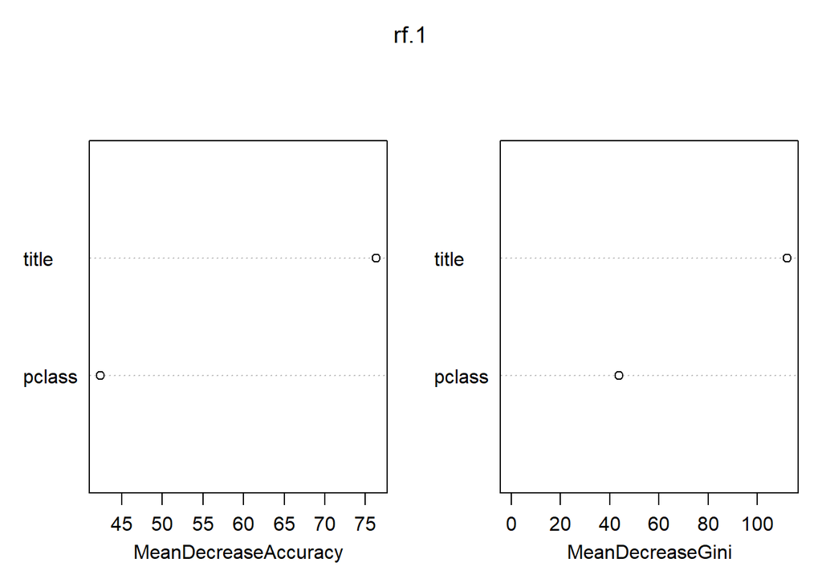

```r
varImpPlot(rf.1)
```

### 3.2.1 What is OOB

Out-of-bag (OOB) error, also called out-of-bag estimate, is a method of measuring the prediction error of random forests, boosted decision trees, and other machine learning models utilizing bootstrap aggregating (bagging) to sub-sample data samples used for training.

### 3.2.2 Analysis rf.1 with predictors title and pclass

OOB error estimate is 20.31 and title is more important than pclass for prediction. Now, let’s include sibsp to see if it reduces the error.

## 3.3 2. RandomForest Model with features pclass,title, sibsp

```r
# Train a Random Forest using pclass, title, & sibsp
rf.train.2 <- data.combined[1:891, c("pclass", "title", "sibsp")]

set.seed(1234)
rf.2 <- randomForest(x = rf.train.2,
                     y = rf.label,
                     importance = TRUE,
                     ntree = 1000)
rf.2

#saveRDS(rf.2, paste0(path,"/RdsObjects/rf.2.rds"))
```

```r
rf.2 = readRDS(paste0(path,"/RdsObjects/rf.2.rds"))
rf.2
```

```
##
## Call:
##  randomForest(x = rf.train.2, y = rf.label, ntree = 1000, importance = TRUE)
##                Type of random forest: classification
##                      Number of trees: 1000
## No. of variables tried at each split: 1
##
##         OOB estimate of  error rate: 18.63%
## Confusion matrix:
##     0   1 class.error
## 0 489  60   0.1092896
## 1 106 236   0.3099415
```

```r
rf.2.OOB = 18.63

rf.2.accuracy = (489+236)/(489+60+236+106)
rf.2.accuracy = round(rf.2.accuracy*100, 2)
rf.2.accuracy
```

```
## [1] 81.37
```

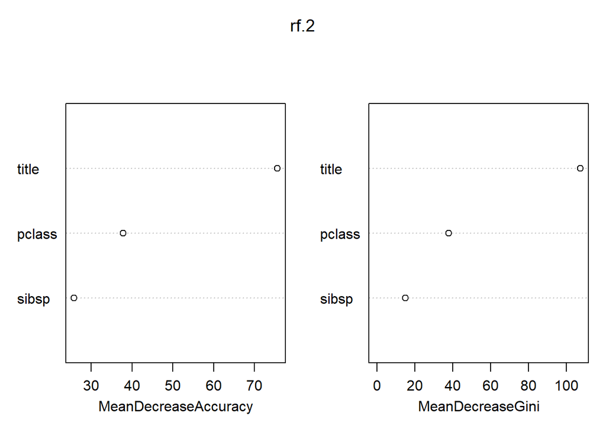

```r
varImpPlot(rf.2)
```

### 3.3.1 Analysis rf.2 with predictors title, pclass and sibsp

OOB error estimate has reduced from 20.31 to 18.63 by including sibsp along with title and pclass

Features by importance are title, pclass, sibsp. Now lets replace sibsp with parch.

## 3.4 3. RandomForest Model with features pclass, title, parch

```r
# Train a Random Forest using pclass, title, & parch
rf.train.3 <- data.combined[1:891, c("pclass", "title", "parch")]

set.seed(1234)
rf.3 <- randomForest(x = rf.train.3, y = rf.label,
                     importance = TRUE,
                     ntree = 1000)
rf.3

saveRDS(rf.3, paste0(path,"/RdsObjects/rf.3.rds"))
```

```r
rf.3 = readRDS(paste0(path,"/RdsObjects/rf.3.rds"))
rf.3
```

```
##
## Call:
##  randomForest(x = rf.train.3, y = rf.label, ntree = 1000, importance = TRUE)
##                Type of random forest: classification
##                      Number of trees: 1000
## No. of variables tried at each split: 1
##
##         OOB estimate of  error rate: 19.3%
## Confusion matrix:
##     0   1 class.error
## 0 492  57   0.1038251
## 1 115 227   0.3362573
```

```r
rf.3.OOB = 19.3

rf.3.accuracy = (492+227)/(489+57+115+227)
rf.3.accuracy = round(rf.3.accuracy*100, 2)
rf.3.accuracy
```

```
## [1] 80.97
```

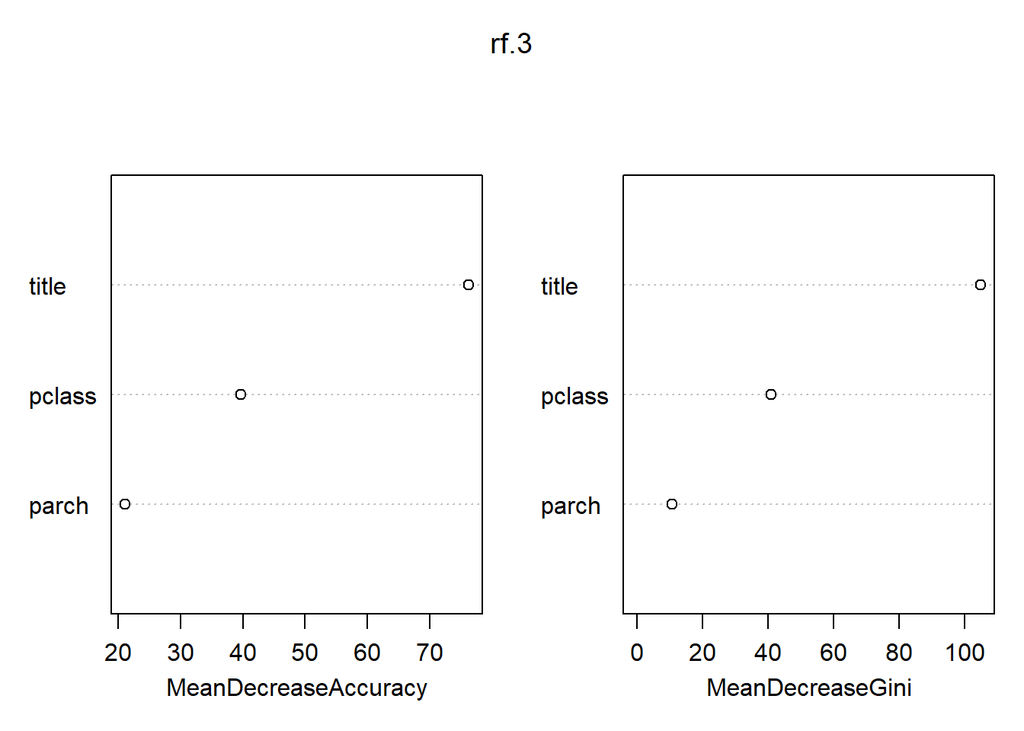

```r
varImpPlot(rf.3)
```

OOB error estimate has increase from 18.63 to 19.3, so title, pclass and sibsp have better predictive power than title,pclass, parch.

Features by importance title, pclass, parch.

Let’s test will all four features title, pclass, sibsp, parch

## 3.5 4. RandomForest Model with features pclass, title, sibsp, parch

```r
# Train a Random Forest using pclass, title, sibsp, parch
rf.train.4 <- data.combined[1:891, c("pclass", "title", "sibsp", "parch")]

set.seed(1234)
rf.4 <- randomForest(x = rf.train.4, y = rf.label, importance = TRUE, ntree = 1000)
rf.4

saveRDS(rf.4, paste0(path,"/RdsObjects/rf.4.rds"))
```

```r
rf.4 = readRDS(paste0(path,"/RdsObjects/rf.4.rds"))
rf.4
```

```
##
## Call:
##  randomForest(x = rf.train.4, y = rf.label, ntree = 1000, importance = TRUE)
##                Type of random forest: classification
##                      Number of trees: 1000
## No. of variables tried at each split: 2
##
##         OOB estimate of  error rate: 18.41%
## Confusion matrix:
##     0   1 class.error
## 0 490  59   0.1074681
## 1 105 237   0.3070175
```

```r
rf.4.OOB = 18.41

rf.4.accuracy = (490+237)/(490+59+105+237)
rf.4.accuracy = round(rf.4.accuracy*100, 2)
rf.4.accuracy
```

```
## [1] 81.59
```

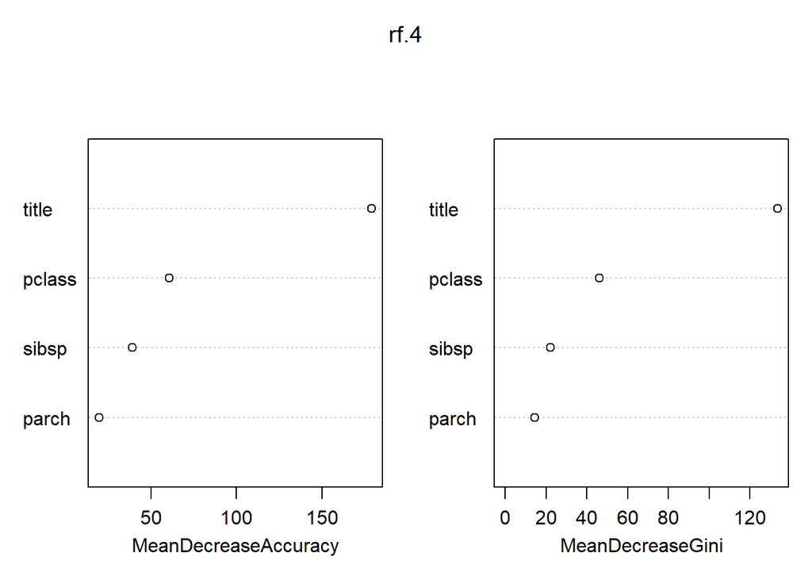

```r
varImpPlot(rf.4)
```

### 3.5.1 Analysis rf.4 with predictors title, pclass, sibsp and parch

OOB error estimate is lowest so far with all the four features 18.41 compared to 18.63 with title pclass sibsp.

Now let’s try with another feature family.size along with title and pclass. family size is derived from sibsp and parch, so let’s see if it has better predictive power than them.

As expected features by importance ar title, pclass, sibsp, parch

## 3.6 5. RandomForest Model with pclass, title and derived feature family.size

```r
# Train a Random Forest using pclass, title, & family.size
rf.train.5 <- data.combined[1:891, c("pclass", "title", "family.size")]

set.seed(1234)
rf.5 <- randomForest(x = rf.train.5, y = rf.label, importance = TRUE, ntree = 1000)
rf.5

saveRDS(rf.5, paste0(path,"/RdsObjects/rf.5.rds"))
```

```r
rf.5 = readRDS(paste0(path,"/RdsObjects/rf.5.rds"))
rf.5
```

```
##
## Call:
##  randomForest(x = rf.train.5, y = rf.label, ntree = 1000, importance = TRUE)
##                Type of random forest: classification
##                      Number of trees: 1000
## No. of variables tried at each split: 1
##
##         OOB estimate of  error rate: 18.97%
## Confusion matrix:
##     0   1 class.error
## 0 485  64   0.1165756
## 1 105 237   0.3070175
```

```r
rf.5.OOB = 18.97

rf.5.accuracy = (485+237)/(485+64+105+237)
rf.5.accuracy = round(rf.5.accuracy*100, 2)
rf.5.accuracy
```

```
## [1] 81.03
```

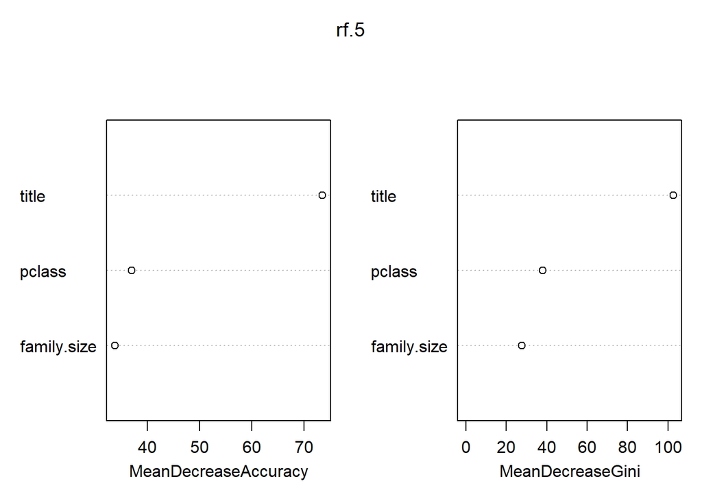

```r
varImpPlot(rf.5)
```

### 3.6.1 Analysis rf.5 with predictors title, pclass and family.size

OOB error estimate has increased a bit with family.size than with sibsp, and importance is still title, pclass. Let’s try with sibsp and family.size included.

## 3.7 6.RandomForest Model with pclass, title, sibsp and derived feature family.size

```r
# Train a Random Forest using pclass, title, sibsp, & family.size
rf.train.6 <- data.combined[1:891, c("pclass", "title", "sibsp", "family.size")]

set.seed(1234)
rf.6 <- randomForest(x = rf.train.6, y = rf.label, importance = TRUE, ntree = 1000)
rf.6

saveRDS(rf.6, paste0(path,"/RdsObjects/rf.6.rds"))
```

```r
rf.6 = readRDS(paste0(path,"/RdsObjects/rf.6.rds"))
rf.6
```

```
##
## Call:
##  randomForest(x = rf.train.6, y = rf.label, ntree = 1000, importance = TRUE)
##                Type of random forest: classification
##                      Number of trees: 1000
## No. of variables tried at each split: 2
##
##         OOB estimate of  error rate: 18.41%
## Confusion matrix:
##     0   1 class.error
## 0 487  62   0.1129326
## 1 102 240   0.2982456
```

```r
rf.6.OOB = 18.41

rf.6.accuracy = (487+240)/(487+62+102+240)
rf.6.accuracy = round(rf.6.accuracy*100, 2)
rf.6.accuracy
```

```
## [1] 81.59
```

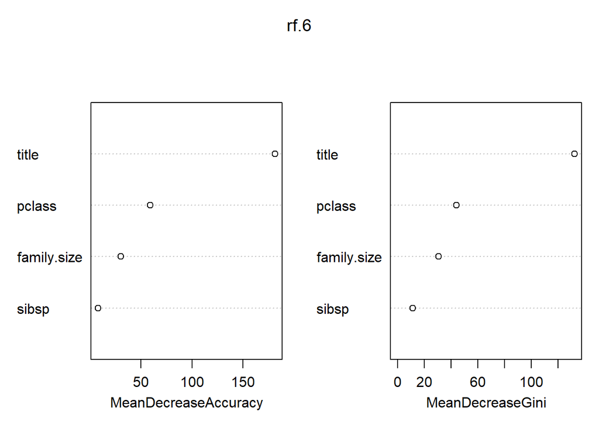

```r
varImpPlot(rf.6)
```

### 3.7.1 Analysis rf.6 with predictors title, pclass, sibsp and family.size

OOB error estimate is less by including sibsp and family.size but family.size is more important than sibsp; title and pclass being most important. Now, let’s include parch instead of sibsp

## 3.8 7.RandomForest Model with pclass, title, parch and derived feature family.size

```r
# Train a Random Forest using pclass, title, parch, & family.size
rf.train.7 <- data.combined[1:891, c("pclass", "title", "parch", "family.size")]

set.seed(1234)
rf.7 <- randomForest(x = rf.train.7, y = rf.label, importance = TRUE, ntree = 1000)
rf.7

saveRDS(rf.7, paste0(path,"/RdsObjects/rf.7.rds"))
```

```r
rf.7 = readRDS(paste0(path,"/RdsObjects/rf.7.rds"))
rf.7
```

```
##
## Call:
##  randomForest(x = rf.train.7, y = rf.label, ntree = 1000, importance = TRUE)
##                Type of random forest: classification
##                      Number of trees: 1000
## No. of variables tried at each split: 2
##
##         OOB estimate of  error rate: 19.08%
## Confusion matrix:
##     0   1 class.error
## 0 487  62   0.1129326
## 1 108 234   0.3157895
```

```r
rf.7.OOB = 19.08

rf.7.accuracy = (487+234)/(487+62+108+234)
rf.7.accuracy = round(rf.7.accuracy*100, 2)
rf.7.accuracy
```

```
## [1] 80.92
```

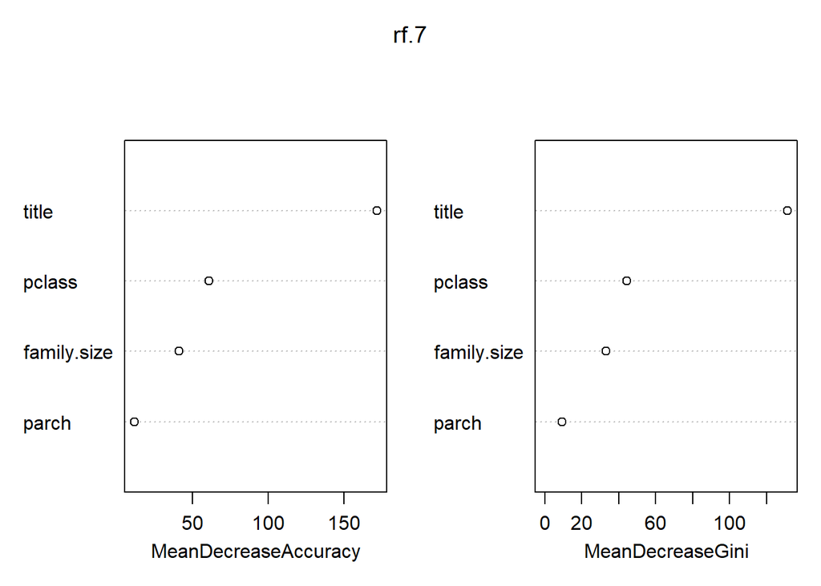

```r
varImpPlot(rf.7)
```

### 3.8.1 Analysis rf.7 with predictors title, pclass, parch and family.size

OOB error estimate has increased with parch instead of sibsp and title, pclass, family.size still most important features. So, we’ll use these three features for our final model - title, pclass, family.size

```r
accuracy = c(rf.1.accuracy, rf.2.accuracy, rf.3.accuracy, rf.4.accuracy,
                  rf.5.accuracy, rf.6.accuracy, rf.7.accuracy)
names(accuracy) = c("rf.1.accu", "rf.2.accu", "rf.3.accu", "rf.4.accu",
                    "rf.5.accu", "rf.6.accu", "rf.7.accu")

OOB = c(rf.1.OOB, rf.2.OOB, rf.3.OOB, rf.4.OOB, rf.5.OOB, rf.6.OOB, rf.7.OOB)

names(OOB) = c("rf.1.OOB", "rf.2.OOB", "rf.3.OOB", "rf.4.OOB", "rf.5.OOB",
               "rf.6.OOB", "rf.7.OOB")



accuracy
```

```
## rf.1.accu rf.2.accu rf.3.accu rf.4.accu rf.5.accu rf.6.accu rf.7.accu
##     79.69     81.37     80.97     81.59     81.03     81.59     80.92
```

```r
str(accuracy)
```

```
##  Named num [1:7] 79.7 81.4 81 81.6 81 ...
##  - attr(*, "names")= chr [1:7] "rf.1.accu" "rf.2.accu" "rf.3.accu" "rf.4.accu" ...
```

```r
class(accuracy)
```

```
## [1] "numeric"
```

```r
sort(accuracy, decreasing = TRUE)
```

```
## rf.4.accu rf.6.accu rf.2.accu rf.5.accu rf.3.accu rf.7.accu rf.1.accu
##     81.59     81.59     81.37     81.03     80.97     80.92     79.69
```

```r
sort(OOB, decreasing = FALSE)
```

```
## rf.4.OOB rf.6.OOB rf.2.OOB rf.5.OOB rf.7.OOB rf.3.OOB rf.1.OOB
##    18.41    18.41    18.63    18.97    19.08    19.30    20.31
```

## 3.9 Which model to pick?

In order of highest accuracy rf.4 and rf.6 have same accuracy

rf.4 - title,plcass,sibsp,parch rf.6 - title, plcass,sibsp,family.size rf.2 - title. pclass, sibsp rf.5 - title.pclass,family.size

In order to avoid overfitting and also since family.size is derived from sibsp and parch, rf.5 is the best model for prediction.

## 3.10 Submission of rf.5

Before we jump into features engineering we need to establish a methodology for estimating our error rate on the test set (i.e., unseen data). This is critical, for without this we are more likely to overfit. Let’s start with a submission of rf.5 to Kaggle to see if our OOB error estimate is accurate.

```r
# rf.5 is trained with pclass, title and family.size
rf.train.5 <- data.combined[1:891, c("pclass", "title", "family.size")]

# Subset our test dataset to include features used in training the model
test.submit.df <- data.combined[892:1309, c("pclass", "title", "family.size")]


# Now predict the label survived using the model

rf.5.preds = predict(rf.5, test.submit.df)
str(rf.5.preds)
```

```
##  Factor w/ 2 levels "0","1": 1 2 1 1 2 1 2 1 2 1 ...
##  - attr(*, "names")= chr [1:418] "892" "893" "894" "895" ...
```

```r
class(rf.5.preds)
```

```
## [1] "factor"
```

```r
table(rf.5.preds)
```

```
## rf.5.preds
##   0   1
## 254 164
```

The result is a vector of factor variable

Write out a CSV file for submission to Kaggle

```r
# Store the results of prediction for label Survived in data frame
submit.df <- data.frame(PassengerId = rep(892:1309), Survived = rf.5.preds)

#write.csv(submit.df, file = "RF_SUB_20160215_1.csv", row.names = FALSE)
write.csv(submit.df, file = "RF_SUB_20190225_1.csv", row.names = FALSE)
```

# 4 Improve the Performace using caret stratified testing

Now that we have decided upon the ensemble model, let’s look at ways to improve the accuracy of the model using cross validation.

## 4.1 Stratified Cross Validation

Cross Validate using caret package

```r
#install.packages("caret")
library(caret)
```

Research has shown that 10-fold CV repeated 10 times is the best place to start, however there are no hard and fast rules - this is where the experience of the Data Scientist (i.e., the ‘art’) comes into play. We’ll start with 10-fold CV, repeated 10 times and see how it goes.

Leverage caret to create 100 total folds, but ensure that the ratio of those that survived and perished in each fold matches the overall training set. This is known as stratified cross validation and generally provides better results.

```r
# Proportion of label
table(rf.label)
```

```
## rf.label
##   0   1
## 549 342
```

```r
(342/549)*100
```

```
## [1] 62.29508
```

## 4.2 1. Create stratified folds

```r
#Create stratified folds and check if the survival ration is same as in the original

set.seed(2348)

cv.10.folds <- createMultiFolds(rf.label, k = 10, times = 10)

class(cv.10.folds)
```

```
## [1] "list"
```

```r
length(cv.10.folds)
```

```
## [1] 100
```

```r
# What is the 33 rd item in the list
str(cv.10.folds[[33]])
```

```
##  int [1:802] 1 2 3 4 5 6 7 8 9 10 ...
```

Integer Vector

```r
head(cv.10.folds[[33]], 40)
```

```
##  [1]  1  2  3  4  5  6  7  8  9 10 11 12 13 14 15 16 17 18 19 20 21 22 23
## [24] 24 25 26 27 29 30 31 32 33 34 35 36 37 38 39 40 41
```

It is arrary of numbers to be used to index test dataset for training the model with 10 fold cv. It may look like all numbers are included but if you look closely few indexs are missing like 28.

```r
# Check stratification for 33rd fold
table(rf.label[cv.10.folds[[33]]])
```

```
##
##   0   1
## 494 308
```

```r
(308/494)*100
```

```
## [1] 62.34818
```

## 4.3 2. Set up trainControl

```r
# Set up caret's trainControl object for the cv folds we created above.
ctrl.1 <- trainControl(method = "repeatedcv", number = 10, repeats = 10,
                       index = cv.10.folds)
```

Set up doSNOW package for multi-core training. This is helpful as we’re going to be training a lot of trees. NOTE - This works on Windows and Mac, unlike doMC

## 4.4 3. Parallel Execution

```r
#install.packages("doSNOW")
library(doSNOW)
```

### 4.4.1 1. Parallel processing with three sockets cluster and 10-fold CV

```r
#cl <- makeCluster(6, type = "SOCK")
cl <- makeCluster(3, type = "SOCK")
registerDoSNOW(cl)


# Set seed for reproducibility and train
set.seed(34324)
rf.5.cv.1 <- train(x = rf.train.5, y = rf.label, method = "rf", tuneLength = 3,
                   ntree = 1000, trControl = ctrl.1)

#Shutdown cluster
stopCluster(cl)

# Check out results
rf.5.cv.1

saveRDS(rf.5.cv.1,  paste0(path,"/RdsObjects/rf.5.cv.1.rds"))
rm(rf.5.cv.1)
rf.5.cv.1
```

```r
rf.5.cv.1 = readRDS(paste0(path,"/RdsObjects/rf.5.cv.1.rds"))
rf.5.cv.1
```

```
## Random Forest
##
## 891 samples
##   3 predictor
##   2 classes: '0', '1'
##
## No pre-processing
## Resampling: Cross-Validated (10 fold, repeated 10 times)
## Summary of sample sizes: 801, 802, 802, 803, 802, 801, ...
## Resampling results across tuning parameters:
##
##   mtry  Accuracy   Kappa
##   2     0.8143776  0.5985065
##   3     0.8104560  0.5883278
##
## Accuracy was used to select the optimal model using the largest value.
## The final value used for the model was mtry = 2.
```

```r
#With the three features: mtry = 3

rf.5.cv.1.accuracy = 0.8104*100
rf.5.cv.1.accuracy
```

```
## [1] 81.04
```

```r
rf.5.accuracy
```

```
## [1] 81.03
```

```r
set.seed(5983)
cv.5.folds <- createMultiFolds(rf.label, k = 5, times = 10)

ctrl.2 <- trainControl(method = "repeatedcv", number = 5, repeats = 10,
                       index = cv.5.folds)

cl <- makeCluster(6, type = "SOCK")
registerDoSNOW(cl)

set.seed(89472)
rf.5.cv.2 <- train(x = rf.train.5, y = rf.label, method = "rf", tuneLength = 3,
                   ntree = 1000, trControl = ctrl.2)

#Shutdown cluster
stopCluster(cl)

# Check out results
rf.5.cv.2

saveRDS(rf.5.cv.2,  paste0(path,"/RdsObjects/rf.5.cv.2.rds"))
rm(rf.5.cv.2)
rf.5.cv.2
```

```r
rf.5.cv.2 = readRDS(paste0(path,"/RdsObjects/rf.5.cv.2.rds"))
rf.5.cv.2
```

```
## Random Forest
##
## 891 samples
##   3 predictor
##   2 classes: '0', '1'
##
## No pre-processing
## Resampling: Cross-Validated (5 fold, repeated 10 times)
## Summary of sample sizes: 713, 713, 713, 713, 712, 713, ...
## Resampling results across tuning parameters:
##
##   mtry  Accuracy   Kappa
##   2     0.8152691  0.6015662
##   3     0.8107753  0.5906653
##
## Accuracy was used to select the optimal model using the largest value.
## The final value used for the model was mtry = 2.
```

```r
rf.5.cv.2.accuracy = 0.8107*100
rf.5.cv.2.accuracy
```

```
## [1] 81.07
```

```r
rf.5.cv.1.accuracy
```

```
## [1] 81.04
```

```r
rf.5.accuracy
```

```
## [1] 81.03
```

```r
set.seed(37596)
cv.3.folds <- createMultiFolds(rf.label, k = 3, times = 10)

ctrl.3 <- trainControl(method = "repeatedcv", number = 3, repeats = 10,
                       index = cv.3.folds)

cl <- makeCluster(6, type = "SOCK")
registerDoSNOW(cl)

set.seed(94622)
rf.5.cv.3 <- train(x = rf.train.5, y = rf.label, method = "rf", tuneLength = 3,
                   ntree = 64, trControl = ctrl.3)

#Shutdown cluster
stopCluster(cl)

# Check out results
rf.5.cv.3

saveRDS(rf.5.cv.3,  paste0(path,"/RdsObjects/rf.5.cv.3.rds"))
rm(rf.5.cv.3)
rf.5.cv.3
```

```r
rf.5.cv.3 = readRDS(paste0(path,"/RdsObjects/rf.5.cv.3.rds"))
rf.5.cv.3
```

```
## Random Forest
##
## 891 samples
##   3 predictor
##   2 classes: '0', '1'
##
## No pre-processing
## Resampling: Cross-Validated (3 fold, repeated 10 times)
## Summary of sample sizes: 594, 594, 594, 594, 594, 594, ...
## Resampling results across tuning parameters:
##
##   mtry  Accuracy   Kappa
##   2     0.8116723  0.5899932
##   3     0.8067340  0.5781929
##
## Accuracy was used to select the optimal model using the largest value.
## The final value used for the model was mtry = 2.
```

With three features, mtry = 3

```r
rf.5.cv.3.accuracy = 0.807*100
rf.5.cv.3.accuracy
```

```
## [1] 80.7
```

```r
rf.5.cv.2.accuracy
```

```
## [1] 81.07
```

```r
rf.5.cv.1.accuracy
```

```
## [1] 81.04
```

```r
rf.5.accuracy
```

```
## [1] 81.03
```

# 5 Exploratory Modeling 2 : Using Decision Tree (instead of RF ensemble modeling)

To see if further feature engineering will help us build better models or not Decision trees allow us to see the effect of features better than rf though there is risk of overfitting. randomForest builds many decision tress with different combinations of features hence it counters the effect of overfitting but it is not intuitive hence to explore the effect of features we’ll use decision trees we see that family.size predicts family.size greater than 4 for pclass 3 all perish this is case of overfitting so we will focus on title.

## 5.1 Why Single Decision Tree?

Let’s use a single decision tree to better understand what’s going on with our features. Obviously Random Forests are far more powerful than single trees, but single trees have the advantage of being easier to understand.

```r
#install.packages("rpart")
#install.packages("rpart.plot")
library(rpart)
library(rpart.plot)
# Create utility function
rpart.cv <- function(seed, training, labels, ctrl) {
  cl <- makeCluster(3, type = "SOCK")
  registerDoSNOW(cl)

  set.seed(seed)
  # Leverage formula interface for training
  rpart.cv <- train(x = training, y = labels, method = "rpart", tuneLength = 30,
                    trControl = ctrl)

  #Shutdown cluster
  stopCluster(cl)

  return (rpart.cv)
}
```

## 5.2 1. Let’s use 3-fold CV repeated 10 times

```r
# Grab features
features <- c("pclass", "title", "family.size")
rpart.train.1 <- data.combined[1:891, features]

# Run CV and check out results
#rpart.cv <- function(seed, training, labels, ctrl)
rpart.1.cv.1 <- rpart.cv(94622, rpart.train.1, rf.label, ctrl.3)
rpart.1.cv.1

saveRDS(rpart.1.cv.1,  paste0(path,"/RdsObjects/rpart.1.cv.1.rds"))
rm(rpart.1.cv.1)
rpart.1.cv.1
```

```r
rpart.1.cv.1 = readRDS(paste0(path,"/RdsObjects/rpart.1.cv.1.rds"))
rpart.1.cv.1
```

```
## CART
##
## 891 samples
##   3 predictor
##   2 classes: '0', '1'
##
## No pre-processing
## Resampling: Cross-Validated (3 fold, repeated 10 times)
## Summary of sample sizes: 594, 594, 594, 594, 594, 594, ...
## Resampling results across tuning parameters:
##
##   cp          Accuracy   Kappa
##   0.00000000  0.8066218  0.5819237
##   0.01492236  0.8106622  0.5934361
##   0.02984473  0.8125701  0.5985773
##   0.04476709  0.8034792  0.5816483
##   0.05968945  0.7865320  0.5477887
##   0.07461182  0.7866442  0.5498171
##   0.08953418  0.7866442  0.5498171
##   0.10445654  0.7811448  0.5406399
##   0.11937891  0.7787879  0.5368224
##   0.13430127  0.7786756  0.5369699
##   0.14922363  0.7786756  0.5369699
##   0.16414600  0.7786756  0.5369699
##   0.17906836  0.7786756  0.5369699
##   0.19399072  0.7786756  0.5369699
##   0.20891309  0.7786756  0.5369699
##   0.22383545  0.7786756  0.5369699
##   0.23875781  0.7786756  0.5369699
##   0.25368018  0.7786756  0.5369699
##   0.26860254  0.7786756  0.5369699
##   0.28352490  0.7786756  0.5369699
##   0.29844727  0.7786756  0.5369699
##   0.31336963  0.7786756  0.5369699
##   0.32829199  0.7786756  0.5369699
##   0.34321436  0.7786756  0.5369699
##   0.35813672  0.7786756  0.5369699
##   0.37305908  0.7786756  0.5369699
##   0.38798145  0.7786756  0.5369699
##   0.40290381  0.7722783  0.5169628
##   0.41782617  0.7476992  0.4385410
##   0.43274854  0.7180696  0.3439651
##
## Accuracy was used to select the optimal model using the largest value.
## The final value used for the model was cp = 0.02984473.
```

### 5.2.1 Plot

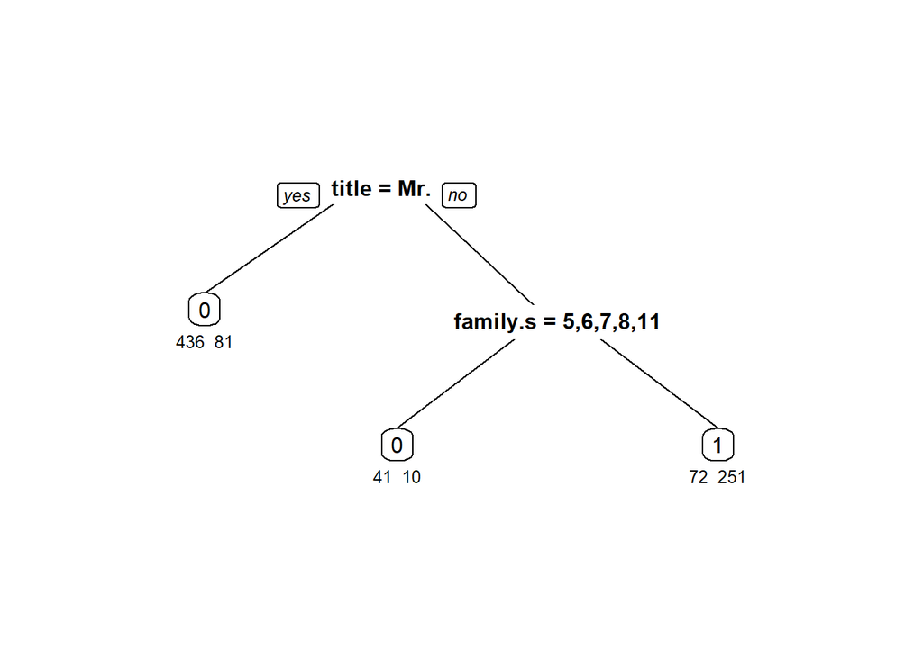

```r
prp(rpart.1.cv.1$finalModel, type = 0, extra = 1, under = TRUE)
```

### 5.2.2 Interpretation

Both rpart and rf confirm that title is important, let’s investigate further

```r
table(data.combined$title)
```

```
##
## Master.   Miss.     Mr.    Mrs.   other
##      61     260     757     197      34
```

```r
# Parse out last name and title
data.combined[1:25, "name"]
```

```
##  [1] "Braund, Mr. Owen Harris"
##  [2] "Cumings, Mrs. John Bradley (Florence Briggs Thayer)"
##  [3] "Heikkinen, Miss. Laina"
##  [4] "Futrelle, Mrs. Jacques Heath (Lily May Peel)"
##  [5] "Allen, Mr. William Henry"
##  [6] "Moran, Mr. James"
##  [7] "McCarthy, Mr. Timothy J"
##  [8] "Palsson, Master. Gosta Leonard"
##  [9] "Johnson, Mrs. Oscar W (Elisabeth Vilhelmina Berg)"
## [10] "Nasser, Mrs. Nicholas (Adele Achem)"
## [11] "Sandstrom, Miss. Marguerite Rut"
## [12] "Bonnell, Miss. Elizabeth"
## [13] "Saundercock, Mr. William Henry"
## [14] "Andersson, Mr. Anders Johan"
## [15] "Vestrom, Miss. Hulda Amanda Adolfina"
## [16] "Hewlett, Mrs. (Mary D Kingcome) "
## [17] "Rice, Master. Eugene"
## [18] "Williams, Mr. Charles Eugene"
## [19] "Vander Planke, Mrs. Julius (Emelia Maria Vandemoortele)"
## [20] "Masselmani, Mrs. Fatima"
## [21] "Fynney, Mr. Joseph J"
## [22] "Beesley, Mr. Lawrence"
## [23] "McGowan, Miss. Anna \"Annie\""
## [24] "Sloper, Mr. William Thompson"
## [25] "Palsson, Miss. Torborg Danira"
```

```r
name.splits <- str_split(data.combined$name, ",")
name.splits[1]
```

```
## [[1]]
## [1] "Braund"           " Mr. Owen Harris"
```

```r
last.names <- sapply(name.splits, "[", 1)
last.names[1:10]
```

```
##  [1] "Braund"    "Cumings"   "Heikkinen" "Futrelle"  "Allen"
##  [6] "Moran"     "McCarthy"  "Palsson"   "Johnson"   "Nasser"
```

```r
# Add last names to dataframe in case we find it useful later
data.combined$last.name <- last.names

# Now for titles
name.splits <- str_split(sapply(name.splits, "[", 2), " ")
titles <- sapply(name.splits, "[", 2)
unique(titles)
```

```
##  [1] "Mr."       "Mrs."      "Miss."     "Master."   "Don."
##  [6] "Rev."      "Dr."       "Mme."      "Ms."       "Major."
## [11] "Lady."     "Sir."      "Mlle."     "Col."      "Capt."
## [16] "the"       "Jonkheer." "Dona."
```

```r
# What's up with a title of 'the'?
data.combined[which(titles == "the"),]
```

```
##     survived pclass
## 760        1      1
##                                                         name    sex age
## 760 Rothes, the Countess. of (Lucy Noel Martha Dyer-Edwards) female  33
##     sibsp parch ticket fare cabin embarked title family.size
## 760     0     0 110152 86.5   B77        S other           1
##     ticket.first.char cabin.first.char cabin.multiple last.name
## 760                 1                B              N    Rothes
```

```r
# Re-map titles to be more exact
titles[titles %in% c("Dona.", "the")] <- "Lady."
titles[titles %in% c("Ms.", "Mlle.")] <- "Miss."
titles[titles == "Mme."] <- "Mrs."
titles[titles %in% c("Jonkheer.", "Don.")] <- "Sir."
titles[titles %in% c("Col.", "Capt.", "Major.")] <- "Officer"
table(titles)
```

```
## titles
##     Dr.   Lady. Master.   Miss.     Mr.    Mrs. Officer    Rev.    Sir.
##       8       3      61     264     757     198       7       8       3
```

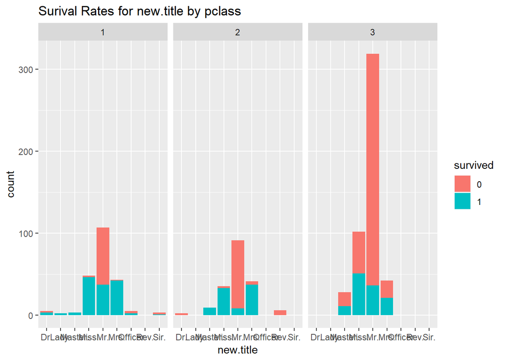

```r
# Make title a factor
data.combined$new.title <- as.factor(titles)

# Visualize new version of title
ggplot(data.combined[1:891,], aes(x = new.title, fill = survived)) +
  geom_bar() +
  facet_wrap(~ pclass) +
  ggtitle("Surival Rates for new.title by pclass")
```

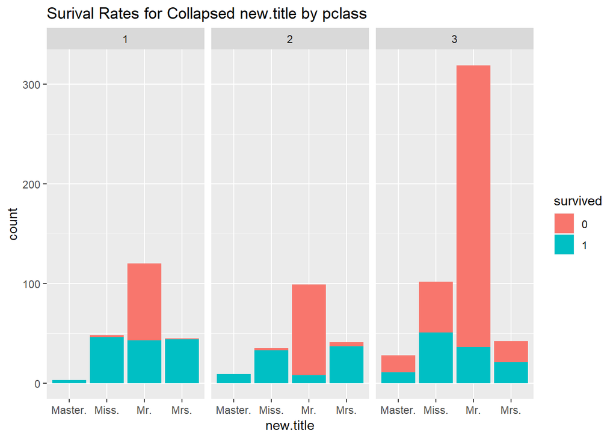

```r
# Collapse titles based on visual analysis
indexes <- which(data.combined$new.title == "Lady.")
data.combined$new.title[indexes] <- "Mrs."

indexes <- which(data.combined$new.title == "Dr." |
                   data.combined$new.title == "Rev." |
                   data.combined$new.title == "Sir." |
                   data.combined$new.title == "Officer")
data.combined$new.title[indexes] <- "Mr."

# Visualize
ggplot(data.combined[1:891,], aes(x = new.title, fill = survived)) +
  geom_bar() +
  facet_wrap(~ pclass) +
  ggtitle("Surival Rates for Collapsed new.title by pclass")
```

```r
# Grab features
features <- c("pclass", "new.title", "family.size")
rpart.train.2 <- data.combined[1:891, features]

# Run CV and check out results
#rpart.cv <- function(seed, training, labels, ctrl)
rpart.2.cv.1 <- rpart.cv(94622, rpart.train.2, rf.label, ctrl.3)
rpart.2.cv.1

saveRDS(rpart.2.cv.1,  paste0(path,"/RdsObjects/rpart.2.cv.1.rds"))
rm(rpart.2.cv.1)
rpart.2.cv.1
```

```r
rpart.2.cv.1 = readRDS(paste0(path,"/RdsObjects/rpart.2.cv.1.rds"))
rpart.2.cv.1
```

```
## CART
##
## 891 samples
##   3 predictor
##   2 classes: '0', '1'
##
## No pre-processing
## Resampling: Cross-Validated (3 fold, repeated 10 times)
## Summary of sample sizes: 594, 594, 594, 594, 594, 594, ...
## Resampling results across tuning parameters:
##
##   cp          Accuracy   Kappa
##   0.00000000  0.8178451  0.6047735
##   0.01582980  0.8261504  0.6252869
##   0.03165961  0.8280584  0.6303902
##   0.04748941  0.8145903  0.6049449
##   0.06331922  0.7936027  0.5633852
##   0.07914902  0.7947250  0.5672045
##   0.09497883  0.7939394  0.5658414
##   0.11080863  0.7929293  0.5641059
##   0.12663844  0.7924804  0.5634784
##   0.14246824  0.7923681  0.5635873
##   0.15829804  0.7923681  0.5635873
##   0.17412785  0.7923681  0.5635873
##   0.18995765  0.7923681  0.5635873
##   0.20578746  0.7923681  0.5635873
##   0.22161726  0.7923681  0.5635873
##   0.23744707  0.7923681  0.5635873
##   0.25327687  0.7923681  0.5635873
##   0.26910667  0.7923681  0.5635873
##   0.28493648  0.7923681  0.5635873
##   0.30076628  0.7923681  0.5635873
##   0.31659609  0.7923681  0.5635873
##   0.33242589  0.7923681  0.5635873
##   0.34825570  0.7923681  0.5635873
##   0.36408550  0.7923681  0.5635873
##   0.37991531  0.7923681  0.5635873
##   0.39574511  0.7923681  0.5635873
##   0.41157491  0.7923681  0.5635873
##   0.42740472  0.7719416  0.5013069
##   0.44323452  0.7271605  0.3617107
##   0.45906433  0.7025814  0.2840360
##
## Accuracy was used to select the optimal model using the largest value.
## The final value used for the model was cp = 0.03165961.
```

### 5.2.3 Plot

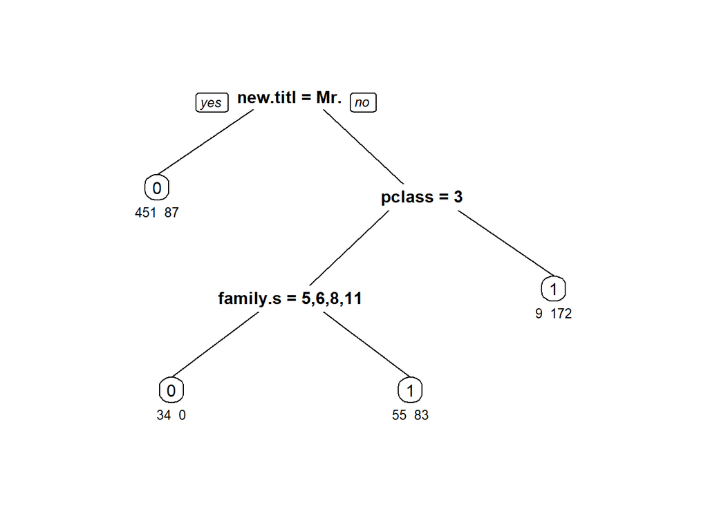

```r
prp(rpart.2.cv.1$finalModel, type = 0, extra = 1, under = TRUE)
```

# 6 Further feature engineering of title

```r
# Dive in on 1st class Mr."
indexes.first.mr <- which(data.combined$new.title == "Mr."
                          & data.combined$pclass == "1")
first.mr.df <- data.combined[indexes.first.mr, ]
summary(first.mr.df)
```

```
##  survived  pclass      name               sex           age        sibsp
##  0   :77   1:175   Length:175         female:  1   Min.   :17.00   0:122
##  1   :43   2:  0   Class :character   male  :174   1st Qu.:31.00   1: 50
##  None:55   3:  0   Mode  :character                Median :42.00   2:  2
##                                                    Mean   :42.24   3:  1
##                                                    3rd Qu.:50.50   4:  0
##                                                    Max.   :80.00   5:  0
##                                                    NA's   :28      8:  0
##      parch        ticket               fare           cabin
##  0      :146   Length:175         Min.   :  0.00   Length:175
##  1      : 21   Class :character   1st Qu.: 27.72   Class :character
##  2      :  6   Mode  :character   Median : 45.50   Mode  :character
##  3      :  1                      Mean   : 67.35
##  4      :  1                      3rd Qu.: 78.07
##  5      :  0                      Max.   :512.33
##  (Other):  0
##    embarked             title      family.size  ticket.first.char
##  Length:175         Master.:  0   1      :109   1      :110
##  Class :character   Miss.  :  0   2      : 45   P      : 45
##  Mode  :character   Mr.    :159   3      : 16   3      :  8
##                     Mrs.   :  0   4      :  2   6      :  4
##                     other  : 16   6      :  2   2      :  3
##                                   5      :  1   F      :  2
##                                   (Other):  0   (Other):  3
##  cabin.first.char cabin.multiple  last.name           new.title
##  C      :47       N:162          Length:175         Mr.    :175
##  U      :44       Y: 13          Class :character   Dr.    :  0
##  B      :27                      Mode  :character   Lady.  :  0
##  D      :20                                         Master.:  0
##  E      :19                                         Miss.  :  0
##  A      :17                                         Mrs.   :  0
##  (Other): 1                                         (Other):  0
```

```r
# One female?
first.mr.df[first.mr.df$sex == "female",]
```

```
##     survived pclass                        name    sex age sibsp parch
## 797        1      1 Leader, Dr. Alice (Farnham) female  49     0     0
##     ticket    fare cabin embarked title family.size ticket.first.char
## 797  17465 25.9292   D17        S other           1                 1
##     cabin.first.char cabin.multiple last.name new.title
## 797                D              N    Leader       Mr.
```

```r
# Update new.title feature
indexes <- which(data.combined$new.title == "Mr." &
                   data.combined$sex == "female")
data.combined$new.title[indexes] <- "Mrs."

# Any other gender slip ups?
length(which(data.combined$sex == "female" &
               (data.combined$new.title == "Master." |
                  data.combined$new.title == "Mr.")))
```

```
## [1] 0
```

```r
# Refresh data frame
indexes.first.mr <- which(data.combined$new.title == "Mr." & data.combined$pclass == "1")
first.mr.df <- data.combined[indexes.first.mr, ]

# Let's look at surviving 1st class "Mr."
summary(first.mr.df[first.mr.df$survived == "1",])
```

```
##  survived  pclass     name               sex          age        sibsp
##  0   : 0   1:42   Length:42          female: 0   Min.   :17.00   0:28
##  1   :42   2: 0   Class :character   male  :42   1st Qu.:28.00   1:13
##  None: 0   3: 0   Mode  :character               Median :36.00   2: 1
##                                                  Mean   :38.76   3: 0
##                                                  3rd Qu.:48.00   4: 0
##                                                  Max.   :80.00   5: 0
##                                                  NA's   :5       8: 0
##      parch       ticket               fare           cabin
##  0      :36   Length:42          Min.   : 26.29   Length:42
##  1      : 4   Class :character   1st Qu.: 27.34   Class :character
##  2      : 2   Mode  :character   Median : 35.50   Mode  :character
##  3      : 0                      Mean   : 71.55
##  4      : 0                      3rd Qu.: 73.39
##  5      : 0                      Max.   :512.33
##  (Other): 0
##    embarked             title     family.size ticket.first.char
##  Length:42          Master.: 0   1      :25   1      :30
##  Class :character   Miss.  : 0   2      :12   P      :11
##  Mode  :character   Mr.    :37   3      : 4   2      : 1
##                     Mrs.   : 0   4      : 1   3      : 0
##                     other  : 5   5      : 0   4      : 0
##                                  6      : 0   5      : 0
##                                  (Other): 0   (Other): 0
##  cabin.first.char cabin.multiple  last.name           new.title
##  C      :10       N:39           Length:42          Mr.    :42
##  E      : 8       Y: 3           Class :character   Dr.    : 0
##  B      : 7                      Mode  :character   Lady.  : 0
##  D      : 6                                         Master.: 0
##  U      : 6                                         Miss.  : 0
##  A      : 5                                         Mrs.   : 0
##  (Other): 0                                         (Other): 0
```

```r
View(first.mr.df[first.mr.df$survived == "1",])
```

### 6.0.1 Feature engineering of fares

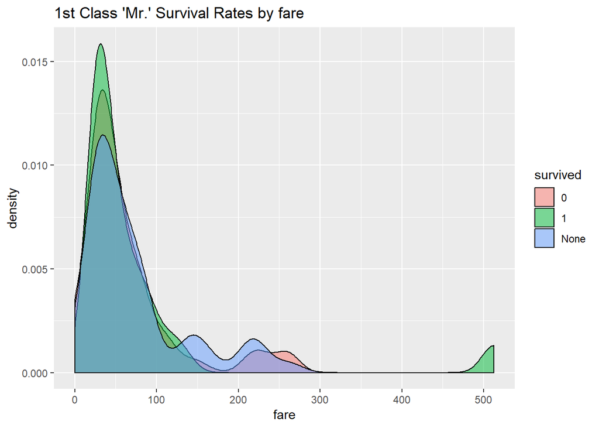

```r
# Take a look at some of the high fares
indexes <- which(data.combined$ticket == "PC 17755" |
                   data.combined$ticket == "PC 17611" |
                   data.combined$ticket == "113760")
View(data.combined[indexes,])

# Visualize survival rates for 1st class "Mr." by fare
ggplot(first.mr.df, aes(x = fare, fill = survived)) +
  geom_density(alpha = 0.5) +
  ggtitle("1st Class 'Mr.' Survival Rates by fare")
```

### 6.0.2 Engineer features based on all the passengers with the same ticket

```r
ticket.party.size <- rep(0, nrow(data.combined))
avg.fare <- rep(0.0, nrow(data.combined))
tickets <- unique(data.combined$ticket)

for (i in 1:length(tickets)) {
  current.ticket <- tickets[i]
  party.indexes <- which(data.combined$ticket == current.ticket)
  current.avg.fare <- data.combined[party.indexes[1], "fare"] / length(party.indexes)

  for (k in 1:length(party.indexes)) {
    ticket.party.size[party.indexes[k]] <- length(party.indexes)
    avg.fare[party.indexes[k]] <- current.avg.fare
  }
}

data.combined$ticket.party.size <- ticket.party.size
data.combined$avg.fare <- avg.fare

# Refresh 1st class "Mr." dataframe
first.mr.df <- data.combined[indexes.first.mr, ]
summary(first.mr.df)
```

```
##  survived  pclass      name               sex           age        sibsp
##  0   :77   1:174   Length:174         female:  0   Min.   :17.00   0:121
##  1   :42   2:  0   Class :character   male  :174   1st Qu.:31.00   1: 50
##  None:55   3:  0   Mode  :character                Median :42.00   2:  2
##                                                    Mean   :42.20   3:  1
##                                                    3rd Qu.:50.75   4:  0
##                                                    Max.   :80.00   5:  0
##                                                    NA's   :28      8:  0
##      parch        ticket               fare           cabin
##  0      :145   Length:174         Min.   :  0.00   Length:174
##  1      : 21   Class :character   1st Qu.: 27.72   Class :character
##  2      :  6   Mode  :character   Median : 46.30   Mode  :character
##  3      :  1                      Mean   : 67.58
##  4      :  1                      3rd Qu.: 78.46
##  5      :  0                      Max.   :512.33
##  (Other):  0
##    embarked             title      family.size  ticket.first.char
##  Length:174         Master.:  0   1      :108   1      :109
##  Class :character   Miss.  :  0   2      : 45   P      : 45
##  Mode  :character   Mr.    :159   3      : 16   3      :  8
##                     Mrs.   :  0   4      :  2   6      :  4
##                     other  : 15   6      :  2   2      :  3
##                                   5      :  1   F      :  2
##                                   (Other):  0   (Other):  3
##  cabin.first.char cabin.multiple  last.name           new.title
##  C      :47       N:161          Length:174         Mr.    :174
##  U      :44       Y: 13          Class :character   Dr.    :  0
##  B      :27                      Mode  :character   Lady.  :  0
##  D      :19                                         Master.:  0
##  E      :19                                         Miss.  :  0
##  A      :17                                         Mrs.   :  0
##  (Other): 1                                         (Other):  0
##  ticket.party.size    avg.fare
##  Min.   :1.000     Min.   :  0.00
##  1st Qu.:1.000     1st Qu.: 26.43
##  Median :1.500     Median : 29.29
##  Mean   :1.902     Mean   : 32.36
##  3rd Qu.:2.000     3rd Qu.: 37.59
##  Max.   :7.000     Max.   :128.08
##
```

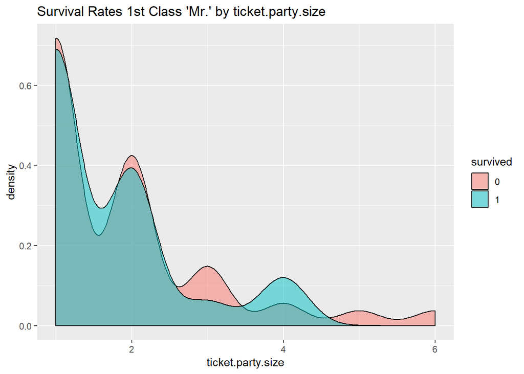

```r
# Visualize new features
ggplot(first.mr.df[first.mr.df$survived != "None",], aes(x = ticket.party.size, fill = survived)) +
  geom_density(alpha = 0.5) +
  ggtitle("Survival Rates 1st Class 'Mr.' by ticket.party.size")
```

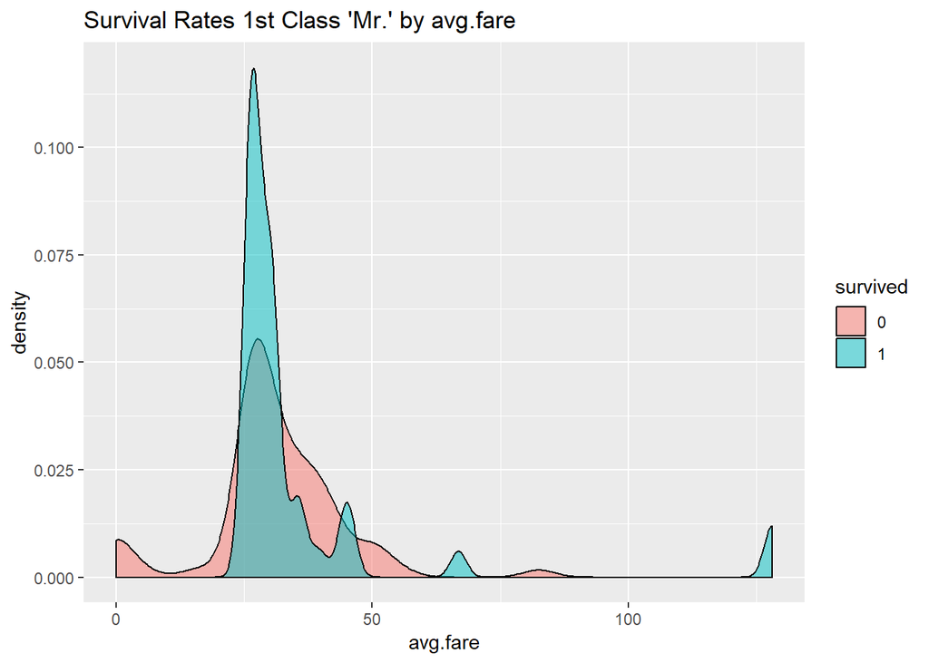

```r
ggplot(first.mr.df[first.mr.df$survived != "None",], aes(x = avg.fare, fill = survived)) +
  geom_density(alpha = 0.5) +
  ggtitle("Survival Rates 1st Class 'Mr.' by avg.fare")
```

### 6.0.3 Hypothesis - ticket.party.size is highly correlated with avg.fare

```r
summary(data.combined$avg.fare)
```

```
##    Min. 1st Qu.  Median    Mean 3rd Qu.    Max.    NA's
##    0.00    7.55    8.05   14.76   15.01  128.08       1
```

```r
# One missing value, take a look
data.combined[is.na(data.combined$avg.fare), ]
```

```
##      survived pclass               name  sex  age sibsp parch ticket fare
## 1044     None      3 Storey, Mr. Thomas male 60.5     0     0   3701   NA
##      cabin embarked title family.size ticket.first.char cabin.first.char
## 1044     U        S   Mr.           1                 3                U
##      cabin.multiple last.name new.title ticket.party.size avg.fare
## 1044              N    Storey       Mr.                 1       NA
```

```r
# Get records for similar passengers and summarize avg.fares
indexes <- with(data.combined, which(pclass == "3" & title == "Mr." & family.size == 1 &
                                       ticket != "3701"))
similar.na.passengers <- data.combined[indexes,]
summary(similar.na.passengers$avg.fare)
```

```
##    Min. 1st Qu.  Median    Mean 3rd Qu.    Max.
##   0.000   7.250   7.840   7.717   8.050  10.171
```

```r
# Use median since close to mean and a little higher than mean
data.combined[is.na(avg.fare), "avg.fare"] <- 7.840
```

### 6.0.4 Normalize the newly created features using preProcess caret function

```r
str(data.combined$ticket.party.size)
```

```
##  num [1:1309] 1 2 1 2 1 1 2 5 3 2 ...
```

```r
head(data.combined$ticket.party.size)
```

```
## [1] 1 2 1 2 1 1
```

```r
summary(data.combined$ticket.party.size)
```

```
##    Min. 1st Qu.  Median    Mean 3rd Qu.    Max.
##   1.000   1.000   1.000   2.102   3.000  11.000
```

```r
str(data.combined$avg.fare)
```

```
##  num [1:1309] 7.25 35.64 7.92 26.55 8.05 ...
```

```r
head(data.combined$avg.fare)
```

```
## [1]  7.25000 35.64165  7.92500 26.55000  8.05000  8.45830
```

```r
summary(data.combined$avg.fare)
```

```
##    Min. 1st Qu.  Median    Mean 3rd Qu.    Max.
##    0.00    7.55    8.05   14.75   15.00  128.08
```

```r
# Normalize numerical variables ticket.party.size and avg.fare
preproc.data.combined <- data.combined[, c("ticket.party.size", "avg.fare")]
preProc <- preProcess(preproc.data.combined, method = c("center", "scale"))

postproc.data.combined <- predict(preProc, preproc.data.combined)


cor(postproc.data.combined$ticket.party.size, postproc.data.combined$avg.fare)
```

```
## [1] 0.09428625
```

0.09 correlation Hypothesis refuted for all data. How about for just 1st class all-up?

```r
indexes <- which(data.combined$pclass == "1")
cor(postproc.data.combined$ticket.party.size[indexes],
    postproc.data.combined$avg.fare[indexes])
```

```
## [1] 0.2576249
```

0.26 correlation. So, hypothesis that ticket.party.size and avg.fare are not correlated for first class. Hypothesis refuted again.

So, let’s see if these two uncorrelated features make any difference to the model accuracy.

# 7 Rpart Model with new features

```r
# OK, let's see if our feature engineering has made any difference
features <- c("pclass", "new.title", "family.size", "ticket.party.size", "avg.fare")
rpart.train.3 <- data.combined[1:891, features]

# Run CV and check out results
#rpart.cv <- function(seed, training, labels, ctrl)
rpart.3.cv.1 <- rpart.cv(94622, rpart.train.3, rf.label, ctrl.3)
rpart.3.cv.1

saveRDS(rpart.3.cv.1,  paste0(path,"/RdsObjects/rpart.3.cv.1.rds"))
rm(rpart.3.cv.1)
rpart.3.cv.1
```

```r
rpart.3.cv.1 = readRDS(paste0(path,"/RdsObjects/rpart.3.cv.1.rds"))
rpart.3.cv.1
```

```
## CART
##
## 891 samples
##   5 predictor
##   2 classes: '0', '1'
##
## No pre-processing
## Resampling: Cross-Validated (3 fold, repeated 10 times)
## Summary of sample sizes: 594, 594, 594, 594, 594, 594, ...
## Resampling results across tuning parameters:
##
##   cp          Accuracy   Kappa
##   0.00000000  0.8214366  0.6170703
##   0.01593063  0.8315376  0.6352241
##   0.03186126  0.8305275  0.6336075
##   0.04779189  0.8157127  0.6070448
##   0.06372252  0.7965208  0.5710962
##   0.07965316  0.7958474  0.5698216
##   0.09558379  0.7950617  0.5684585
##   0.11151442  0.7940516  0.5667230
##   0.12744505  0.7936027  0.5660955
##   0.14337568  0.7934905  0.5662044
##   0.15930631  0.7934905  0.5662044
##   0.17523694  0.7934905  0.5662044
##   0.19116757  0.7934905  0.5662044
##   0.20709821  0.7934905  0.5662044
##   0.22302884  0.7934905  0.5662044
##   0.23895947  0.7934905  0.5662044
##   0.25489010  0.7934905  0.5662044
##   0.27082073  0.7934905  0.5662044
##   0.28675136  0.7934905  0.5662044
##   0.30268199  0.7934905  0.5662044
##   0.31861262  0.7934905  0.5662044
##   0.33454325  0.7934905  0.5662044
##   0.35047389  0.7934905  0.5662044
##   0.36640452  0.7934905  0.5662044
##   0.38233515  0.7934905  0.5662044
##   0.39826578  0.7934905  0.5662044
##   0.41419641  0.7934905  0.5662044
##   0.43012704  0.7730640  0.5039239
##   0.44605767  0.7534231  0.4431483
##   0.46198830  0.6858586  0.2299565
##
## Accuracy was used to select the optimal model using the largest value.
## The final value used for the model was cp = 0.01593063.
```

## 7.1 Plot

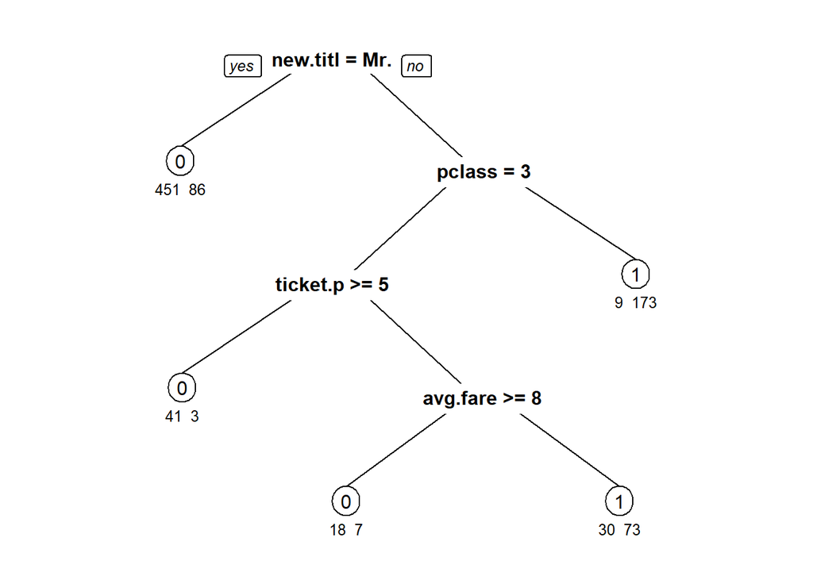

```r
prp(rpart.3.cv.1$finalModel, type = 0, extra = 1, under = TRUE)
```

## 7.2 Submission

```r
# Subset our test records and features
test.submit.df <- data.combined[892:1309, features]

# Make predictions
rpart.3.preds <- predict(rpart.3.cv.1$finalModel, test.submit.df, type = "class")
table(rpart.3.preds)

# Write out a CSV file for submission to Kaggle
submit.df <- data.frame(PassengerId = rep(892:1309), Survived = rpart.3.preds)

write.csv(submit.df, file = "RPART_SUB_20160619_1.csv", row.names = FALSE)
```

Rpart scores 0.80383

# 8 RandomForest Model with new features

```r
features <- c("pclass", "new.title", "ticket.party.size", "avg.fare")
rf.train.temp <- data.combined[1:891, features]

set.seed(1234)
rf.temp <- randomForest(x = rf.train.temp, y = rf.label, ntree = 1000)
rf.temp

saveRDS(rf.temp,  paste0(path,"/RdsObjects/rf.temp.rds"))
rm(rf.temp)
rf.temp
```

```r
rf.temp = readRDS(paste0(path,"/RdsObjects/rf.temp.rds"))
rf.temp


test.submit.df <- data.combined[892:1309, features]

# Make predictions
rf.preds <- predict(rf.temp, test.submit.df)
table(rf.preds)

# Write out a CSV file for submission to Kaggle
submit.df <- data.frame(PassengerId = rep(892:1309), Survived = rf.preds)

write.csv(submit.df, file = "RF_SUB_20160619_1.csv", row.names = FALSE)
```

Random forest scores 0.80861.

## 8.1 Submitting, scoring, and some analysis.

Feature engineering using mutual information - look at ytube videos on FE or feature selection entropy and dimensional reduction using rtsne library

# 9 See titanic-improving-model.rmd